I am using Simple ITK because it supports a large number of filters that facilitate classical segmentation algorithms (variety of thresholding algorithms, watersheds). And after the segmenstation we can easily post process the segmentation.

# Linking to drive

```python
from google.colab import drive

drive.mount('/content/drive')
```

```python
cd /content/drive/My Drive/skillsEval/skillsEval
```

```
/content/drive/My Drive/skillsEval/skillsEval
```

# Importing Libraries And Reading Image

```python
!pip install simpleitk
```

```
     |████████████████████████████████| 48.4 MB 19 kB/s
```

Since I was not able to visualise properly (display properly) the segmented image from the matplotlib so I also tried to visualise from gui.py.

```python
run gui.py
```

Here I read the bacteria.mha file through sitk.readImage and then tried to display it's one slice using matplotlib

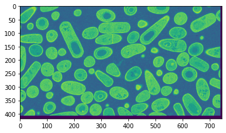

```python
from google.colab.patches import cv2_imshow
import SimpleITK as sitk
import pylab
z = 0
image_origin = sitk.ReadImage("bacteria.mha")
slice = sitk.GetArrayFromImage(image_origin)[z,:,:]
plt.imshow(slice)
#cv2_imshow(slice)
```

Here I displayed the original bacteria.mha file using gui.py

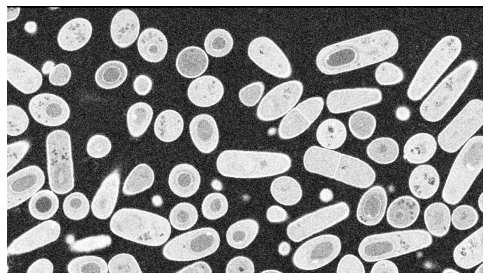

```python
MultiImageDisplay(image_list = [image_origin], figure_size=(8,4));
```

# Separate the Bacteria from the Background

By seeing the original image we can see that the background can be separated by using single intensity threshold. SO we will first confirm it by plotting the intensity distribution using sitk.GetArrayViewFromImage and matplotlib

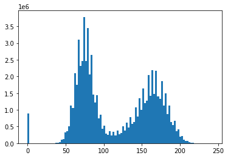

```python
plt.figure()
plt.hist(sitk.GetArrayViewFromImage(image_origin).flatten(), bins=100)
plt.show()
```

The histogram has a clear separation. And we can see the sepration is intuitively between 110 to 120. So i tried with the intensity value of 111 and tried to visualise using matplotlib

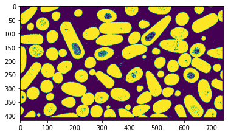

```python
import cv2
bacteriamask = image_origin > 111
z = 0
slice1 = sitk.GetArrayFromImage(bacteriamask)[z,:,:]
plt.imshow(slice1)
#img = cv2.imread('bacteria.mha', cv2.IMREAD_UNCHANGED)
#cv2_imshow(slice1)

#plt.imshow(brainmask, cmap = cm.Greys_r);
```

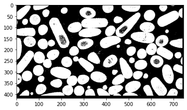

```python
import matplotlib.cm as cm

plt.imshow((slice1), cmap= cm.Greys_r)
```

Now since the SimpleITK also has options for various filters like Otsu, Huang etc I tried using from these filter also and tried to display it using the matplotlib

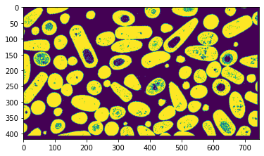

```python
threshold_filters = {'Otsu': sitk.OtsuThresholdImageFilter(),'Triangle' : sitk.TriangleThresholdImageFilter(),'Huang' : sitk.HuangThresholdImageFilter(),'MaxEntropy' : sitk.MaximumEntropyThresholdImageFilter()}
try:
  thresh_filter = threshold_filters['MaxEntropy']
  thresh_filter.SetInsideValue(0)
  thresh_filter.SetOutsideValue(1)
  thresh_img = thresh_filter.Execute(image_origin)
  thresh_value = thresh_filter.GetThreshold()
except KeyError:
  thresh_value = 120
  thresh_img = image_origin<thresh_value
slice2 = sitk.GetArrayFromImage(thresh_img)[z,:,:]
plt.imshow(slice2)
```

Now I visualised the same figure using gui.py

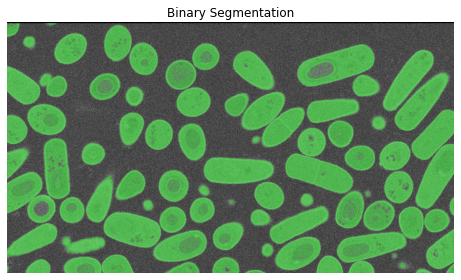

```python
MultiImageDisplay(image_list = [sitk.LabelOverlay(image_origin, thresh_img)],
                      title_list = ['Binary Segmentation'], figure_size=(8,4));
```

# Marking each bacteria with unique label and evaluate

Here I tried to look at the distribution of sizes of bacteria(conected components)

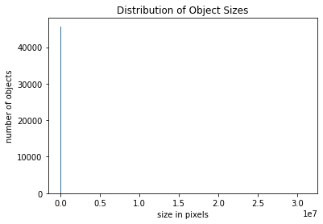

```python
stats = sitk.LabelShapeStatisticsImageFilter()
stats.Execute(sitk.ConnectedComponent(bacteriamask))

# Look at the distribution of sizes of connected components (bacteria).
label_sizes = [ stats.GetNumberOfPixels(l) for l in stats.GetLabels() if l != 1]

plt.figure()
plt.hist(label_sizes,bins=200)
plt.title("Distribution of Object Sizes")
plt.xlabel("size in pixels")
plt.ylabel("number of objects")
plt.show()
```

We can see that there are more than 40,000 potential bacterium whose size is very very small so that we could not detect it during the segmentation

# Remove small holes and other noises

Using binary morphological operations we remove small objects using the opening operation and fill small holes using the closing operation.

```python
cleaned_thresh_img = sitk.BinaryOpeningByReconstruction(bacteriamask, [10, 10, 10])
cleaned_thresh_img = sitk.BinaryClosingByReconstruction(cleaned_thresh_img, [10, 10, 10])
```

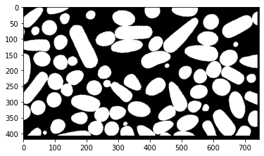

```python
z=0
slice2 = sitk.GetArrayFromImage(cleaned_thresh_img)[z,:,:]

plt.imshow(slice2,cmap='gray')
#cv2_imshow(slice2)
```

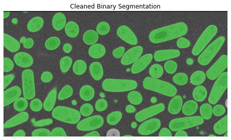

```python
MultiImageDisplay(image_list = [sitk.LabelOverlay(image_origin, cleaned_thresh_img)],title_list = ['Cleaned Binary Segmentation'], figure_size=(8,4));
```

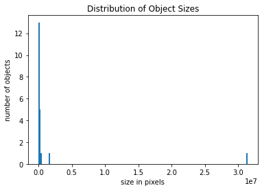

```python
stats = sitk.LabelShapeStatisticsImageFilter()
stats.Execute(sitk.ConnectedComponent(cleaned_thresh_img))

# Look at the distribution of sizes of connected components (bacteria).
label_sizes = [ stats.GetNumberOfPixels(l) for l in stats.GetLabels() if l != 1]

plt.figure()
plt.hist(label_sizes,bins=200)
plt.title("Distribution of Object Sizes")
plt.xlabel("size in pixels")
plt.ylabel("number of objects")
plt.show()
```

Now we can see that after removing thousands of undetected connected components are cleaned and now the number of objects defined by the image is more reasonable.

Now I visualised at the unique bacterium labeled as unique colour

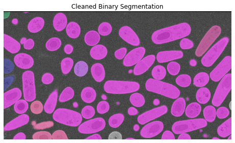

```python
MultiImageDisplay(image_list = [sitk.LabelOverlay(image_origin, sitk.ConnectedComponent(cleaned_thresh_img))],
                      title_list = ['Cleaned Binary Segmentation'],figure_size=(8,4));
```

# Segmenting From each other

Now since the bacteria is segmented from the background it's time to segment it from each other. For this I will be using Seed based watershed segmentation.

```python
dist_img = sitk.SignedMaurerDistanceMap(cleaned_thresh_img != 0, insideIsPositive=False, squaredDistance=False, useImageSpacing=False)
radius = 10
# Seeds have a distance of "radius" or more to the object boundary, they are uniquely labelled.
seeds = sitk.ConnectedComponent(dist_img < -radius)
# Relabel the seed objects using consecutive object labels while removing all objects with less than 15 pixels.
seeds = sitk.RelabelComponent(seeds, minimumObjectSize=15)
# Run the watershed segmentation using the distance map and seeds.
ws = sitk.MorphologicalWatershedFromMarkers(dist_img, seeds, markWatershedLine=True)
ws = sitk.Mask( ws, sitk.Cast(cleaned_thresh_img, ws.GetPixelID()))
```

Visualize the distance map, the unique seeds and final object segmentation.

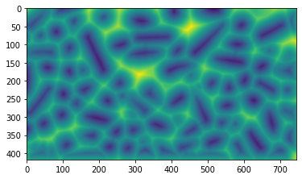

```python
z=0
slice4 = sitk.GetArrayFromImage(dist_img)[z,:,:]
plt.imshow(slice4,)
```

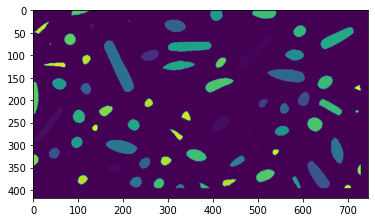

```python
z=0
slice5 = sitk.GetArrayFromImage(seeds)[z,:,:]
plt.imshow(slice5)
```

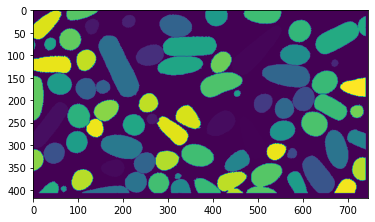

```python
z=0
slice6 = sitk.GetArrayFromImage(ws)[z,:,:]
plt.imshow(slice6)
```

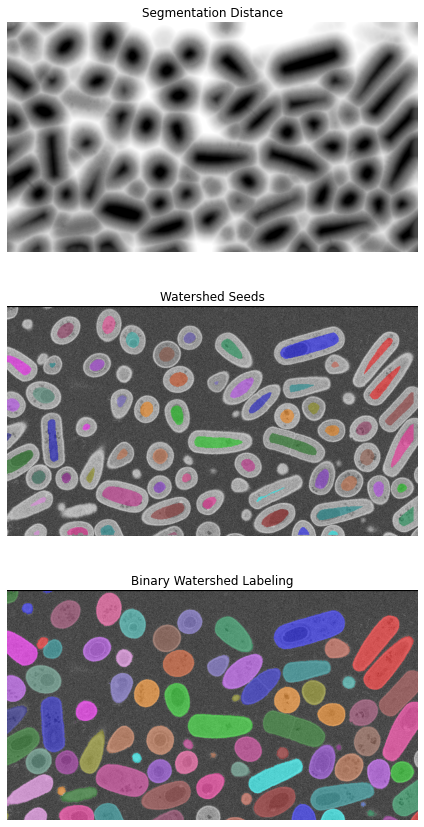

```python
MultiImageDisplay(image_list = [dist_img,
                                    sitk.LabelOverlay(image_origin, seeds),
                                    sitk.LabelOverlay(image_origin, ws)],
                      title_list = ['Segmentation Distance',
                                    'Watershed Seeds',
                                    'Binary Watershed Labeling'],
                      shared_slider=True,
                      horizontal=False,
                      figure_size=(6,12));
```

# Removal of objects touching the image boundary

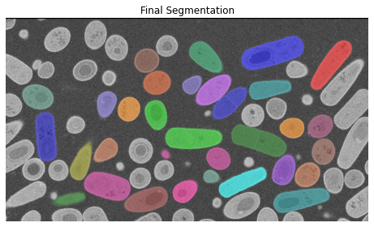

```python
bgp = sitk.BinaryGrindPeak( (ws!=0)| (image_origin==0))
non_border_seg = sitk.Mask( ws, bgp==0)
MultiImageDisplay(image_list = [sitk.LabelOverlay(image_origin, non_border_seg)],
                      title_list = ['Final Segmentation'],figure_size=(8,4));
```

# Shape And Intensity Distribution

```python
shape_stats = sitk.LabelShapeStatisticsImageFilter()
shape_stats.ComputeOrientedBoundingBoxOn()
shape_stats.Execute(ws)

intensity_stats = sitk.LabelIntensityStatisticsImageFilter()
intensity_stats.Execute(ws,image_origin)
```

```python
!pip install pandas
import pandas as pd
```

```python
stats_list = [ (shape_stats.GetPhysicalSize(i),
               shape_stats.GetElongation(i),
               shape_stats.GetFlatness(i),
               shape_stats.GetOrientedBoundingBoxSize(i)[0],
               shape_stats.GetOrientedBoundingBoxSize(i)[2],
               intensity_stats.GetMean(i),
               intensity_stats.GetStandardDeviation(i),
               intensity_stats.GetSkewness(i)) for i in shape_stats.GetLabels()]
cols=["Volume (nm^3)",
      "Elongation",
      "Flatness",
      "Oriented Bounding Box Minimum Size(nm)",
      "Oriented Bounding Box Maximum Size(nm)",
     "Intensity Mean",
     "Intensity Standard Deviation",
     "Intensity Skewness"]

# Create the pandas data frame and display descriptive statistics.
stats = pd.DataFrame(data=stats_list, index=shape_stats.GetLabels(), columns=cols)
stats.describe()
```

|  | Volume (nm^3) | Elongation | Flatness | Oriented Bounding Box Minimum Size(nm) | Oriented Bounding Box Maximum Size(nm) | Intensity Mean | Intensity Standard Deviation | Intensity Skewness |
| --- | --- | --- | --- | --- | --- | --- | --- | --- |
| count | 2.160000e+02 | 216.000000 | 216.000000 | 216.000000 | 216.000000 | 216.000000 | 216.000000 | 216.000000 |
| mean | 8.484990e+08 | 2.086395 | 1.397212 | 821.987756 | 1995.735995 | 161.339739 | 19.732475 | -0.275260 |
| std | 5.139935e+08 | 0.657460 | 0.479751 | 251.754491 | 615.829233 | 6.272832 | 2.109764 | 0.383040 |
| min | 2.809784e+07 | 1.021418 | 1.003342 | 193.242728 | 585.318087 | 135.913009 | 15.893064 | -1.117027 |
| 25% | 3.933966e+08 | 1.506989 | 1.093300 | 635.486328 | 1540.725629 | 157.026166 | 18.156737 | -0.554083 |
| 50% | 8.708485e+08 | 2.140754 | 1.160606 | 928.828298 | 2071.572560 | 163.070286 | 19.584445 | -0.392541 |
| 75% | 1.317612e+09 | 2.536664 | 1.533777 | 1006.225832 | 2500.833406 | 165.809112 | 21.099432 | -0.022149 |
| max | 1.899165e+09 | 3.755361 | 3.161101 | 1300.185066 | 3463.659361 | 172.456032 | 27.521160 | 0.738344 |

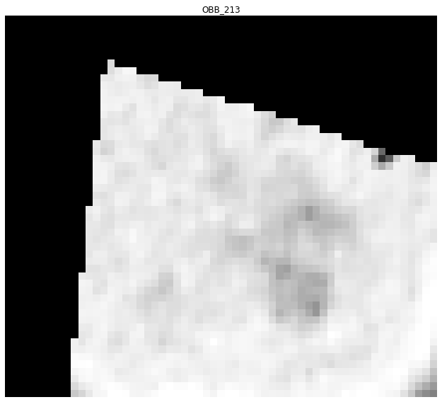

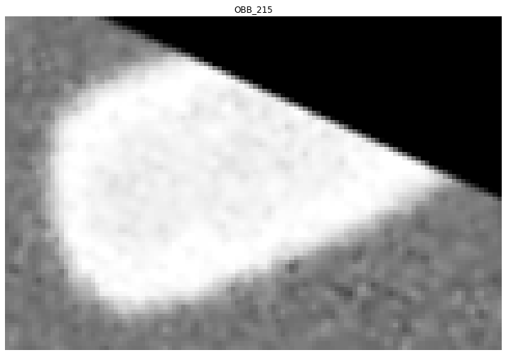

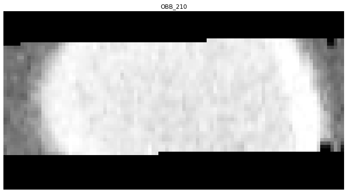

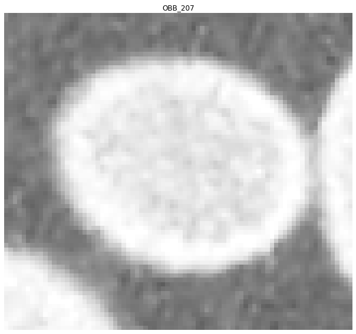

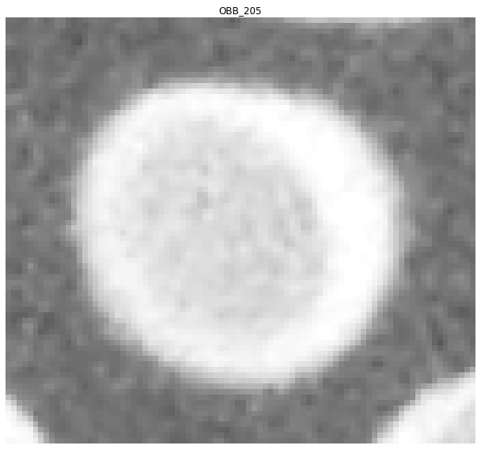

```python
from math import ceil

bacteria_labels = shape_stats.GetLabels()
bacteria_volumes = [shape_stats.GetPhysicalSize(label) for label in bacteria_labels]
num_images = 5 # number of bacteria images we want to display

bacteria_labels_volume_sorted = [label for _,label in sorted(zip(bacteria_volumes, bacteria_labels))]

resampler = sitk.ResampleImageFilter()
aligned_image_spacing = [10,10,10] #in nanometers

for label in bacteria_labels_volume_sorted[0:num_images]:
    aligned_image_size = [ int(ceil(shape_stats.GetOrientedBoundingBoxSize(label)[i]/aligned_image_spacing[i])) for i in range(3) ]
    direction_mat = shape_stats.GetOrientedBoundingBoxDirection(label)
    aligned_image_direction = [direction_mat[0], direction_mat[3], direction_mat[6],
                               direction_mat[1], direction_mat[4], direction_mat[7],
                               direction_mat[2], direction_mat[5], direction_mat[8] ]
    resampler.SetOutputDirection(aligned_image_direction)
    resampler.SetOutputOrigin(shape_stats.GetOrientedBoundingBoxOrigin(label))
    resampler.SetOutputSpacing(aligned_image_spacing)
    resampler.SetSize(aligned_image_size)

    obb_img = resampler.Execute(image_origin)
    # Change the image axes order so that we have a nice display.
    obb_img = sitk.PermuteAxes(obb_img,[2,1,0])
    MultiImageDisplay(image_list = [obb_img],
                          title_list = ["OBB_{0}".format(label)])
```

# Reference

http://insightsoftwareconsortium.github.io/SimpleITK-Notebooks/Python_html/35_Segmentation_Shape_Analysis.html